# Variaveis Instrumentais (Acemoglu et. al.)

Giovanna Quintao

12 de outubro de 2020

$~$

> Esta aula consiste na replicação de parte do artigo “The Colonial Origins of Comparative Development: An Empirical Investigation” (Acemoglu, Johnson e Robinson (2001)). O artigo foi publicado na American Economic Review e ganhou amplo destaque pelo método utilizado e pelos resultados obtidos. A base de dados e os códigos de Stata foi disponibilizado pelos autores [aqui](http://economics.mit.edu/faculty/acemoglu/data/ajr2001).

# Introdução

$~$

```r
#install.packages("ivreg")
library(tidyverse) #pacote para arrumar a base de dados
library(stargazer) #pacote para mostrar os resultados das regressões
library(haven) #pacote para abrir bases do stata
library(ggrepel) #pacote para legenda do gráfico
library(ivreg) #pacote de variável instrumental

options(scipen = 999)
```

## Objetivo

$~$

> Estimar o *impacto* das instituições na performance da economia dos países.

## Variáveis utilizadas

$~$ Para perfomance da economia os autores utilizam o PIB per capita baseado na paridade de poder de compra (PPC).

Os autores utilizam como proxy de instituições o índice de proteção contra “risco de expropriação”. Este índice se relaciona com a qualidade das insituições do país, por exemplo, judiciário independente, direito de propriedade e liberdades civis.

## Problema de identificação

$~$ Economias mais ricas tendem a ter melhores instituições, logo como estimar o efeito *causal* entre instituições e PIB? Precisamos de uma variação exógena nas instituições.

Ou seja, precisamos de uma variável *z* que afete as instituições mas não afete *diretamente* a performance na economia. Seja *x* a variável de instituições. Então precisamos de uma variável *z* tal que:

$$(15.4) \qquad cov(z,u)=0$$
$$(15.5) \qquad cov(z,x) \neq 0$$

# Instrumento

$~$

> Instrumento utilizado:

> > taxa de mortalidade dos colonizadores europeus durante a colonização.

Os pressupostos são que: i) onde o ambiente era menos “hostil” à entrada de colonizadores, os colonizadores replicaram insituições europeias com ênfase forte na propriedade privada e no controle do poder do próprio govern; ii) nos países em que o ambiente era mais hostil havia maior probabilidade de se estabelecer uma colonização “extrativista”; iii) as instituições formadas na colonização permanecem até hoje.

> Restrição de exclusão:

> > Condicionalmente aos controles incluídos na regressão, a mortalidade dos colonizadores europeus (acontecimento ocorrido 100 anos atrás) não tem efeito no PIB de 1995, exceto pelo mecanismo das instituições.

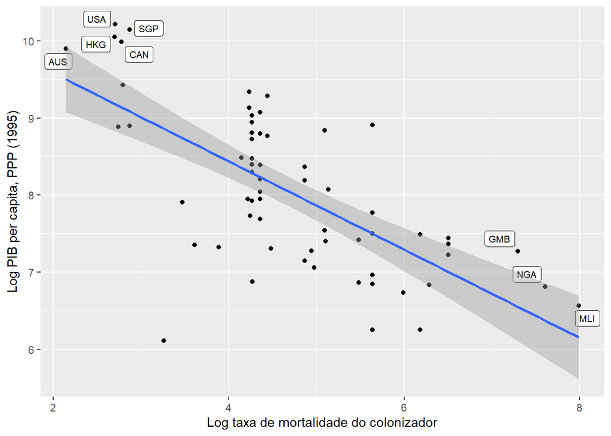

```r
df<-read_dta("aulas_praticas_segundo_semestre/aula_3_VI/maketable1.dta")

ggplot(df%>%filter(baseco==1), aes(y=logpgp95,x=logem4)) +
  geom_point() +
  geom_label_repel(data=subset(df,((baseco==1&logpgp95>=9.8)|baseco==1&logem4>=7)),
                   aes(label =shortnam), size = 2.8, nudge_y = 0)+
  geom_smooth(method="lm",formula = y~x)+
  labs(y="Log PIB per capita, PPP (1995)", x = "Log taxa de mortalidade do colonizador")
```

Vamos visualizar a relação entre a variável instrumental e a variável endógena

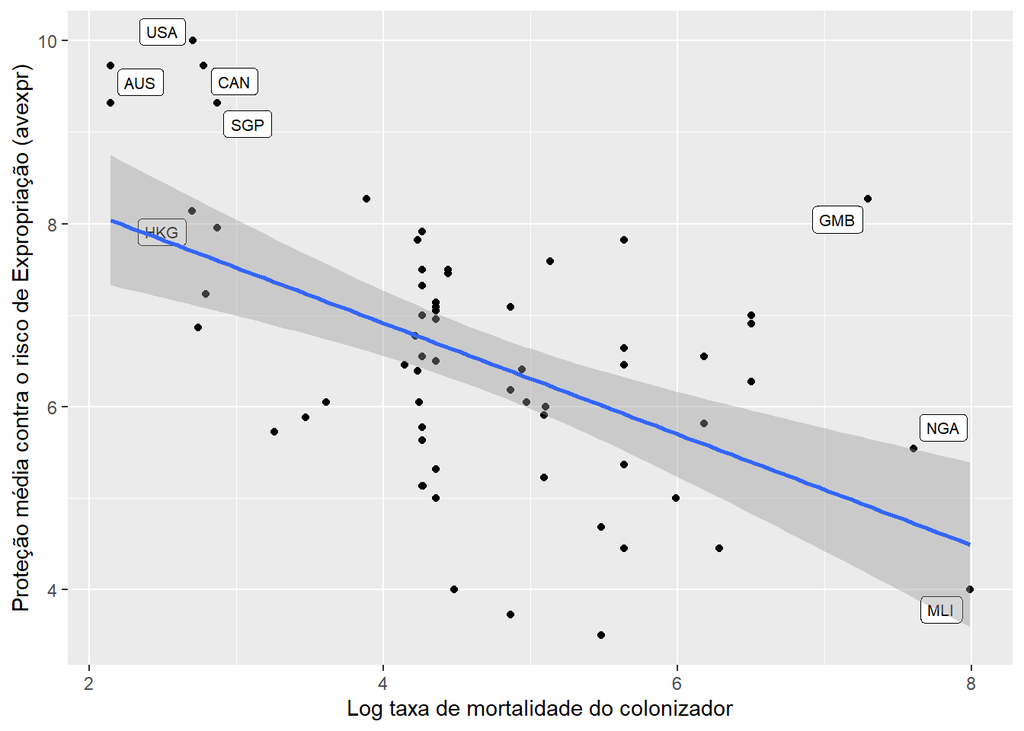

```r
ggplot(df%>%filter(baseco==1), aes(y=avexpr,x=logem4)) +
  geom_point() +
  geom_label_repel(data=subset(df,((baseco==1&logpgp95>=9.8)|baseco==1&logem4>=7)),
                   aes(label =shortnam), size = 2.8, nudge_y = 0)+
  geom_smooth(method="lm",formula = y~x)+
  labs(y="Proteção média contra o risco de Expropriação (avexpr)", x = "Log taxa de mortalidade do colonizador")
```

# Mínimos Quadrados Ordinários

$~$
$$log(y_i)=\mu+\alpha R_i+\textbf{X}_i´\gamma+\epsilon_i \quad (1)$$

$y_i$ é o PIB per capita de cada país $R_i$ é Proteção média contra o risco de Expropriação Médio (avexpr) - qualidade das instituições- $X_i$ é o vetor de outras covariadas

Nota do próprio *do file* disponibilizado pelos autores:

** Note: there are 111 countries in the world sample that have all the necessary data to run the below regressions, though the paper only reports 110 observations. I’m not sure which of the 111 observations is not used in the paper, so the regressions below will use all 111 obs. and won’t quite match the results reported in the paper. **

```r
df<-read_dta("aulas_praticas_segundo_semestre/aula_3_VI/maketable2.dta")

reg<-lm(logpgp95~avexpr,df)

regCOL<-lm(logpgp95~avexpr,df%>%filter(baseco==1))

stargazer(reg,regCOL,type="text",digits=2) #colocando 2 dígitos para ficar igual ao artigo
```

```
##
## =================================================================
##                                  Dependent variable:
##                     ---------------------------------------------
##                                       logpgp95
##                               (1)                    (2)
## -----------------------------------------------------------------
## avexpr                      0.53***                0.52***
##                             (0.04)                 (0.06)
##
## Constant                    4.63***                4.66***
##                             (0.30)                 (0.41)
##
## -----------------------------------------------------------------
## Observations                  111                    64
## R2                           0.61                   0.54
## Adjusted R2                  0.61                   0.53
## Residual Std. Error     0.72 (df = 109)        0.71 (df = 62)
## F Statistic         171.44*** (df = 1; 109) 72.82*** (df = 1; 62)
## =================================================================
## Note:                                 *p<0.1; **p<0.05; ***p<0.01
```

$~$ Os autores estimam a regressão controlando pela latitude (distância do equador), para controlar pelos efeitos diretos entre clima e performance evidenciado por alguns estudiosos (Hall and Jones, 1999). Além disso, controlam pelo continente do país, deixando a América como categoria referência. Vamos fazer estas regressões com os controles:

```r
reg<-lm(logpgp95~avexpr+lat_abst+asia+africa+other,df)

regCOL<-lm(logpgp95~avexpr+lat_abst+asia+africa+other,df%>%filter(baseco==1))

stargazer(reg,regCOL,type="text",digits=2)
```

```
##
## ================================================================
##                                 Dependent variable:
##                     --------------------------------------------
##                                       logpgp95
##                              (1)                    (2)
## ----------------------------------------------------------------
## avexpr                     0.39***                0.40***
##                             (0.05)                (0.06)
##
## lat_abst                     0.33                  0.88
##                             (0.45)                (0.63)
##
## asia                        -0.15                 -0.58**
##                             (0.15)                (0.23)
##
## africa                     -0.92***              -0.88***
##                             (0.17)                (0.17)
##
## other                        0.30                  0.11
##                             (0.37)                (0.38)
##
## Constant                   5.85***                5.74***
##                             (0.34)                (0.40)
##
## ----------------------------------------------------------------
## Observations                 111                    64
## R2                           0.72                  0.71
## Adjusted R2                  0.70                  0.69
## Residual Std. Error    0.63 (df = 105)        0.58 (df = 58)
## F Statistic         52.74*** (df = 5; 105) 28.95*** (df = 5; 58)
## ================================================================
## Note:                                *p<0.1; **p<0.05; ***p<0.01
```

Os resultados mostram correlação entre instituições e PIB per capita.

> Mas porque não podemos tratar este resultado como uma evidência causal?
- Economias mais ricas podem prover melhores instituições
- Variáveis omitidas que são determinantes do PIB e estão relacionadas com instituições
- Problema com a variável de instituições: esta variável foi contruída ex post e os analistas podem ter vieses definindo melhores instituições em melhores países

# Mínimos Quadrados em dois estágios

$~$ Variável endógena: R_i -Proteção média contra o risco de Expropriação (avexpr)-. Pode ser modelada como:

$$R_i= \zeta+\beta log(M_i)+\textbf{X}_i´\delta+\nu_i \qquad (2)$$

> Restrição de exclusão: M_i não aparece em (1)

## Primeiro estágio

$~$

Vamos estimar a relação entre instituições e PIB per capita utilizando variáveis instrumentais. Reproduzindo estimações da tabela 4 (coluna 1 e 8)

```r
df2<-read_dta("aulas_praticas_segundo_semestre/aula_3_VI/maketable4.dta")

df2<-df2 %>% #adicionando a coluna other nesta data frame pois não havia esta informação
  left_join(.,df[,c("shortnam","other")],by="shortnam") %>%
  filter(baseco==1)

first1<-lm(avexpr~logem4,df2)
first2<-lm(avexpr~logem4+lat_abst+asia+africa+other,df2)

stargazer(first1,first2,type="text",digits=2)
```

```
##
## ==============================================================
##                                Dependent variable:
##                     ------------------------------------------
##                                       avexpr
##                              (1)                  (2)
## --------------------------------------------------------------
## logem4                    -0.61***               -0.34*
##                            (0.13)                (0.18)
##
## lat_abst                                          2.01
##                                                  (1.39)
##
## asia                                              0.47
##                                                  (0.50)
##
## africa                                           -0.26
##                                                  (0.41)
##
## other                                             1.06
##                                                  (0.84)
##
## Constant                   9.34***              7.73***
##                            (0.61)                (0.96)
##
## --------------------------------------------------------------
## Observations                 64                    64
## R2                          0.27                  0.33
## Adjusted R2                 0.26                  0.27
## Residual Std. Error    1.26 (df = 62)        1.26 (df = 58)
## F Statistic         22.95*** (df = 1; 62) 5.65*** (df = 5; 58)
## ==============================================================
## Note:                              *p<0.1; **p<0.05; ***p<0.01
```

## Segundo Estágio

$~$ Para fazer o segundo estágio, vamos pegar o $\hat{avexpr}$ estimado da regressão do primeiro estágio.

O indíce 1 se refere a estimação sem controle e 2 com controle.

```r
df2$avexpr1<-first1$fitted.values
df2$avexpr2<-first2$fitted.values
```

Vamos colocar a variável predita na regressão.

```r
second1<-lm(logpgp95~avexpr1,df2)
second2<-lm(logpgp95~avexpr2+lat_abst+asia+africa+other,df2)


stargazer(second1,second2,type="text",digits=2)
```

```
##
## ===============================================================
##                                 Dependent variable:
##                     -------------------------------------------
##                                      logpgp95
##                              (1)                   (2)
## ---------------------------------------------------------------
## avexpr1                    0.94***
##                            (0.13)
##
## avexpr2                                          1.11***
##                                                  (0.30)
##
## lat_abst                                          -1.18
##                                                  (1.14)
##
## asia                                            -1.05***
##                                                  (0.34)
##
## africa                                            -0.44
##                                                  (0.28)
##
## other                                             -0.99
##                                                  (0.65)
##
## Constant                   1.91**                 1.44
##                            (0.82)                (1.84)
##
## ---------------------------------------------------------------
## Observations                 64                    64
## R2                          0.48                  0.58
## Adjusted R2                 0.47                  0.55
## Residual Std. Error    0.76 (df = 62)        0.70 (df = 58)
## F Statistic         56.60*** (df = 1; 62) 16.28*** (df = 5; 58)
## ===============================================================
## Note:                               *p<0.1; **p<0.05; ***p<0.01
```

## Estimações utilizando pacote

$~$

Vamos estimar a mesma relação feita anteriormente mas utilizando o pacote *ivreg* Utilizamos uma *|* para separar os argumentos da função e o instrumento.

```r
vi1<-ivreg(formula=logpgp95~avexpr|logem4,data=df2)

vi2<-ivreg(formula=logpgp95~avexpr+lat_abst+asia+africa+other|logem4+lat_abst+asia+africa+other,data=df2)

stargazer(vi1,vi2,type="text",digits=2)
```

```
##
## =================================================
##                          Dependent variable:
##                     -----------------------------
##                               logpgp95
##                          (1)            (2)
## -------------------------------------------------
## avexpr                 0.94***         1.11**
##                         (0.16)         (0.46)
##
## lat_abst                               -1.18
##                                        (1.76)
##
## asia                                   -1.05*
##                                        (0.52)
##
## africa                                 -0.44
##                                        (0.42)
##
## other                                  -0.99
##                                        (1.00)
##
## Constant                1.91*           1.44
##                         (1.03)         (2.84)
##
## -------------------------------------------------
## Observations              64             64
## R2                       0.19           0.01
## Adjusted R2              0.17          -0.07
## Residual Std. Error 0.95 (df = 62) 1.08 (df = 58)
## =================================================
## Note:                 *p<0.1; **p<0.05; ***p<0.01
```

$~$

Perceba que o erro padrão manual é diferente do erro padrão do pacote. Os erros padrões do segundo estágio feito manualmente não são válidos (Wooldridge explica o motivo na seção 15.3)

# Teste de endogeneidade de Hausman

$~$

Referência: Seção 15.5 (Wooldridge)

Vamos testar se $R$ -Proteção média contra o risco de Expropriação (avexpr)- é endógeno

$$log(y_i)=\mu+\alpha R_i+\textbf{X}_i´\gamma+\epsilon_i \quad (1)$$
$$R_i= \zeta+\beta log(M_i)+\textbf{X}_i´\delta+\nu_i \quad (2)$$

Como $cov(\textbf{X},\epsilon)=0$ para todo X, então $R$ será não correlacionado com $\epsilon \Leftrightarrow corr(\nu,\epsilon)=0$

Vamos estimar a regressão reduzida (2) e salvar o resíduo

```r
first2<-lm(avexpr~logem4+lat_abst+asia+africa+other,df2)

df2$vchapeu<-first2$residuals
```

Vamos verificar se $\nu \text{ e } \epsilon$ são correlacionados colocando o resíduo de (2) ($\hat{\nu}$) na equação estrutural (1).

```r
reg<-lm(logpgp95~avexpr+lat_abst+asia+africa+other+vchapeu,df2)

stargazer(reg,type="text")
```

```
##
## ===============================================
##                         Dependent variable:
##                     ---------------------------
##                              logpgp95
## -----------------------------------------------
## avexpr                       1.107***
##                               (0.232)
##
## lat_abst                      -1.178
##                               (0.880)
##
## asia                         -1.047***
##                               (0.263)
##
## africa                       -0.437**
##                               (0.213)
##
## other                         -0.990*
##                               (0.500)
##
## vchapeu                      -0.748***
##                               (0.239)
##
## Constant                       1.440
##                               (1.423)
##
## -----------------------------------------------
## Observations                    64
## R2                             0.756
## Adjusted R2                    0.730
## Residual Std. Error       0.542 (df = 57)
## F Statistic           29.401*** (df = 6; 57)
## ===============================================
## Note:               *p<0.1; **p<0.05; ***p<0.01
```

Como o coeficiente vchapeu ($\hat{\nu}$) é diferente de zero, podemos concluir que $R$ (-Proteção média contra o risco de Expropriação (avexpr)- é endógeno

# Teste de restrições sobreidentificadoras

$~$ Referência: Seção 15.5 (Wooldridge)

Se tivermos mais instrumentos do que precisamos podemos testar se algum deles não são correlacionados com erro estrutural.

Um dos instrumentos adicionais utilizado pelos autores do artigo é a variável *democ00a*: uma variável dummy que indica se o país era democrático em 1900. Outros 4 instrumentos também foram testados, mas iremos trabalhar só com este.

```r
df<-read_dta("aulas_praticas_segundo_semestre/aula_3_VI/maketable8.dta")

#filtrando a base que contém as informações que precisamos
#na nota da tabela 8 os autores reportam que a estimação com a variável democ00a tem 59 observações
df<-df %>%
  filter(is.na(democ00a)==F) %>%
  filter(is.na(avexpr)==F&is.na(logem4)==F&is.na(logpgp95)==F)

#vamos estimar novamente a regressão com a VI de taxa de mortalidade e salvar os resíduos
vi2<-ivreg(formula=logpgp95~avexpr+lat_abst|logem4+lat_abst,data=df)

df$residuos<-vi2$residuals
```

$~$ Vamos regredir este resíduo sobre todas as variáveis exógenas e obter o $R^2$

```r
aux<-lm(residuos~lat_abst+logem4+democ00a,data=df)

R2_1<-summary(aux)$r.squared
print(R2_1)
```

```
## [1] 0.01929248
```

$~$ Sob a hipótese nula de que todas as VI são não correlacionadas com resíduos do MQ2E (residuos da regressão vi2), temos que $nR_1^2 \thicksim^{a}\mathcal{X}_{(q)}^2$, onde q é o nº de VI fora do modelo - nº endógenas. No nosso caso q=1. Logo a estatística de teste é:

```r
est<-R2_1*nrow(df2)
print(est)
```

```
## [1] 1.234719
```

$~$ Vamos ver como é a distribuição qui-quadrada com um grau de liberdade.

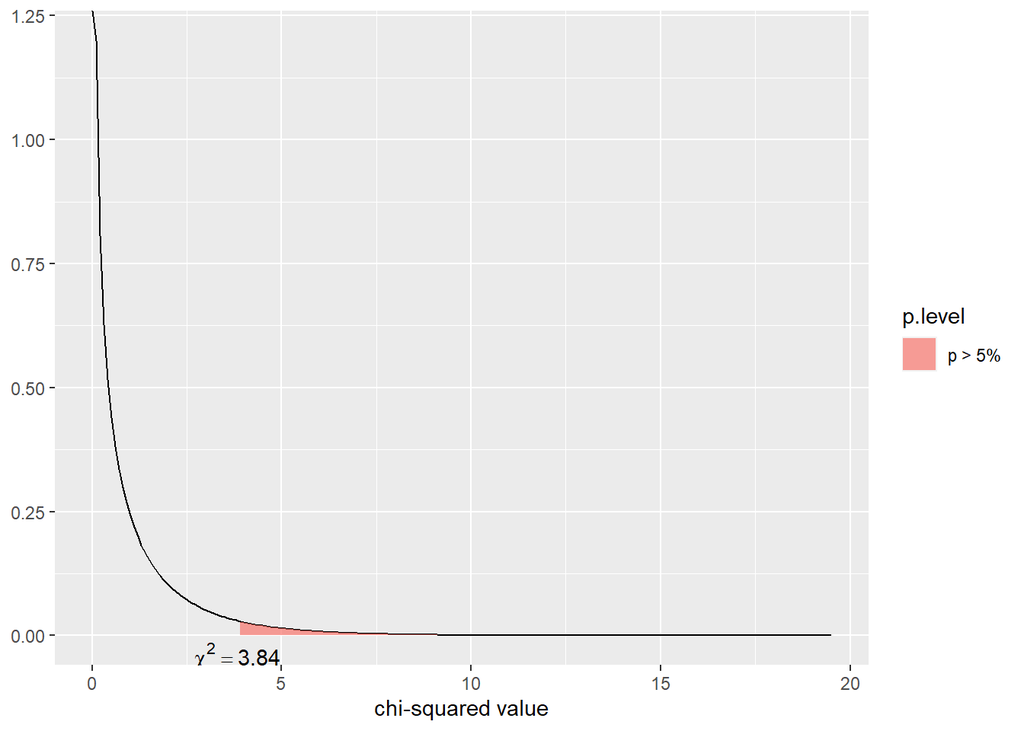

```r
sjPlot::dist_chisq(p=0.05, deg.f = 1)
```

$~$ Como nossa estatística de teste não excede o valor da crítico de 5% da distribuição quiquadrada, não rejeitamos H0 e *não* podemos concluir que pelo menos algumas das VI não são exógenas. Logo as variáveis instrumentais são válidas.

No artigo, o autor apresenta o p-valor deste teste (tabela 8, painel C, coluna 6). Vamos calculá-lo.

```r
round(pchisq(est, df=1, lower.tail=FALSE),2) #o round serve para arredondar
```

```
## [1] 0.27
```

# Considerações finais

$~$ Os autores fazer exercícios de robustez utilizando outras variáveis controles que não foram trabalhadas aqui. Todas as conclusões indicam que reduzir o risco de expropriação iria aumentar significativamente a renda per capita. Para interpretar a magnitude do efeito das instituições, os autores utilizam comparações entre países (uma das razões disso é ser difícil interpretar o que significa 1 ponto percentual a mais no risco de expropriação). Para ter uma ideia do tamanho efeito: Caso a Nigéria tivesse a mesma qualidade das instituições do Chile, no longo prazo, o PIB da Nigéria teria um aumento na sua renda de até 7 vezes.